# Practical Time Series Analysis

Afifa Nur Mila

2024-11-22

# 1. Preparing R (Install and Using Package)

What have i learned? I have learned about: - How to install packages and using it - How to call data in packages and using it

Install package faraway

```r
#install.packages("faraway")
```

Panggil library faraway

```r
library(faraway)
```

Melihat data dalam package faraway

```r
data(package="faraway")
```

Mengambil data coagulation dalam package faraway

```r
coagulation
```

|  | coag | diet |
| --- | --- | --- |
| 1 | 62 | A |
| 2 | 60 | A |
| 3 | 63 | A |
| 4 | 59 | A |
| 5 | 63 | B |
| 6 | 67 | B |
| 7 | 71 | B |
| 8 | 64 | B |
| 9 | 65 | B |
| 10 | 66 | B |

[output cut: 14 more lines]

Plot data coagulation

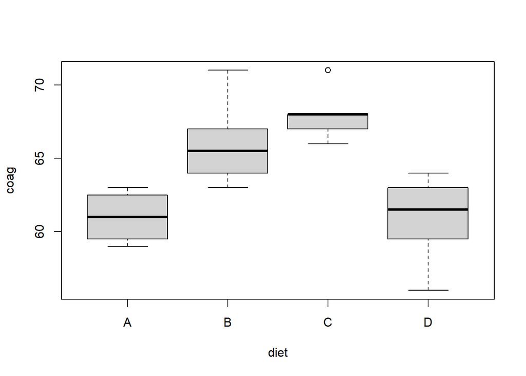

```r
plot(coag~diet, data=coagulation)
```

```r
summary(coagulation)
```

```
##       coag       diet
##  Min.   :56.00   A:4
##  1st Qu.:61.75   B:6
##  Median :63.50   C:6
##  Mean   :64.00   D:8
##  3rd Qu.:67.00
##  Max.   :71.00
```

## Question

Dalam paket jauh, kami memiliki kumpulan data bernama “worldcup” yang memberikan berbagai data R: tentang pemain dari Piala Dunia 2010. Variabel “Time” memberi tahu kita waktu yang dimainkan dalam menit oleh berbagai pemain.

Setelah Anda menginstal dan memuat paket faraway, cari waktu rata-rata yang dimainkan dengan menggunakan perintah

mean(worldcup$Waktu)

Berapa waktu rata-rata yang dimainkan? Anda dapat membulatkan ke 2 atau tiga tempat setelah titik desimal.

Install

```r
#install.packages("worldcup")
```

```r
#library(worldcup)
```

```r
mean(worldcup$Waktu)
```

```
## [1] NA
```

# 2. Introduction to R

What have i learned? I have learned: - How to enter a dataset in R using concatenation c() - How to find five-number summary of a dataset in R using summary() function - How to obtain sample mean and sample standard deviation of a dataset in R using mean() and sd() functions

Commenting in R using #

```r
#this is comment
```

Entering dataset in R using concatenation operator c()

```r
#data={35,8,9,10}
data.1=c(35,8,9,10)

#call data.1
data.1
```

```
## [1] 35  8  9 10
```

Finding summary statistics of data.1

```r
summary(data.1)
```

```
##    Min. 1st Qu.  Median    Mean 3rd Qu.    Max.
##    8.00    8.75    9.50   15.50   16.25   35.00
```

Finding mean

```r
mean(data.1)
```

```
## [1] 15.5
```

Other way of finding mean

```r
sum(data.1)/4
```

```
## [1] 15.5
```

Finding standar deviation of data.1

```r
sd(data.1)
```

```
## [1] 13.02562
```

# 3. Histogram in R

What have i learned? I have learned about: - how to find histogram of a dataset with frequencies or probability on the y-axis - how to change the bin width in a histogram - how to impose a smooth density over a histogram - how change colour and line width in a histogram.

We have a small dataset like this

```r
small.size.dataset=c(91,49,76,112,97,42,70, 100, 8, 112, 95, 90, 78, 62, 56, 94, 65, 58, 109, 70, 109, 91, 71, 76, 68, 62, 134, 57, 83, 66)
```

Make a histogram from the dataset

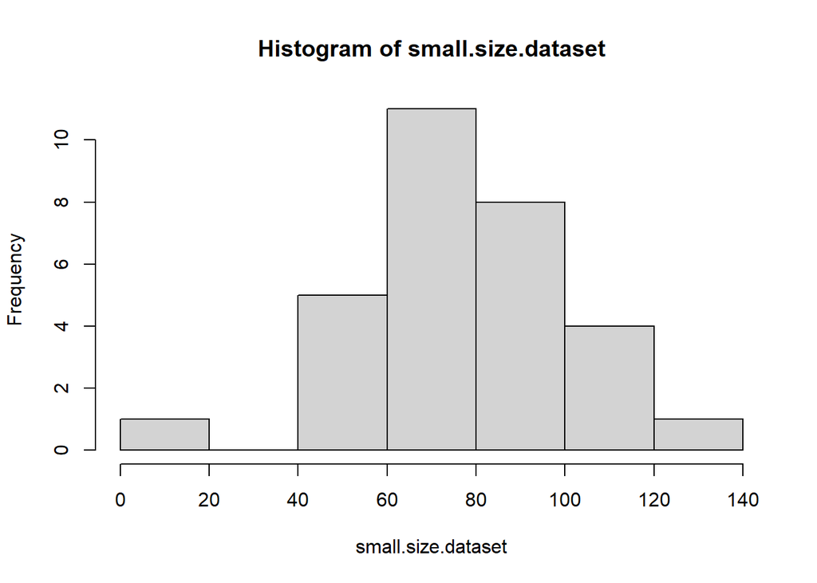

```r
hist(small.size.dataset)
```

Change X-label name

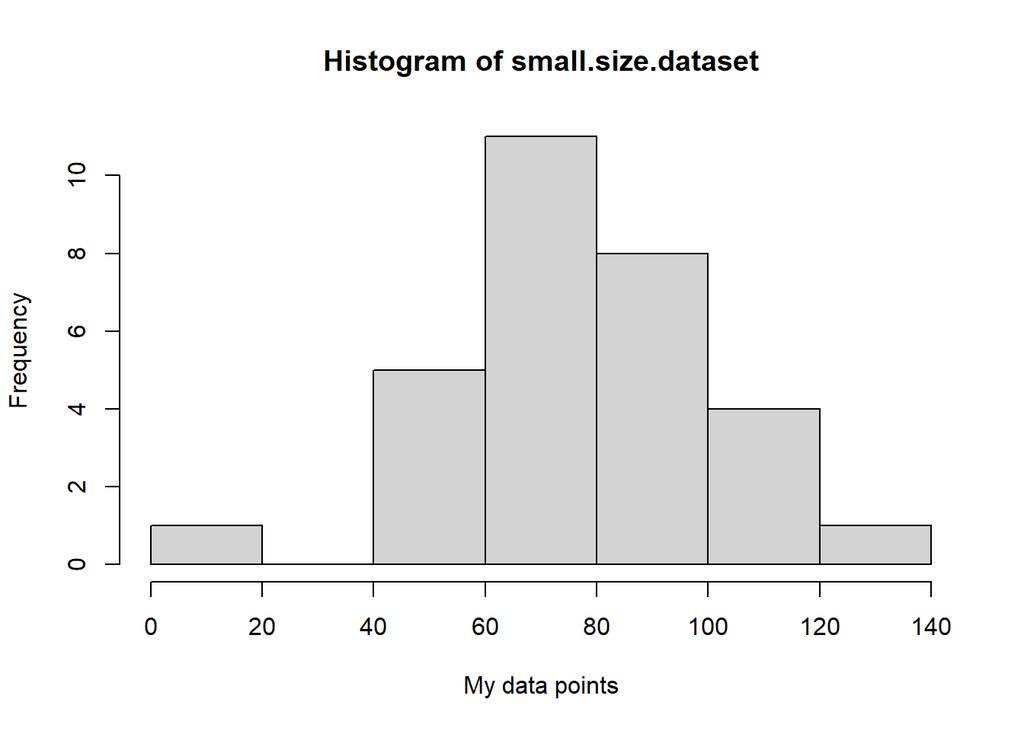

```r
hist(small.size.dataset, xlab='My data points')
```

Change title of the histogram

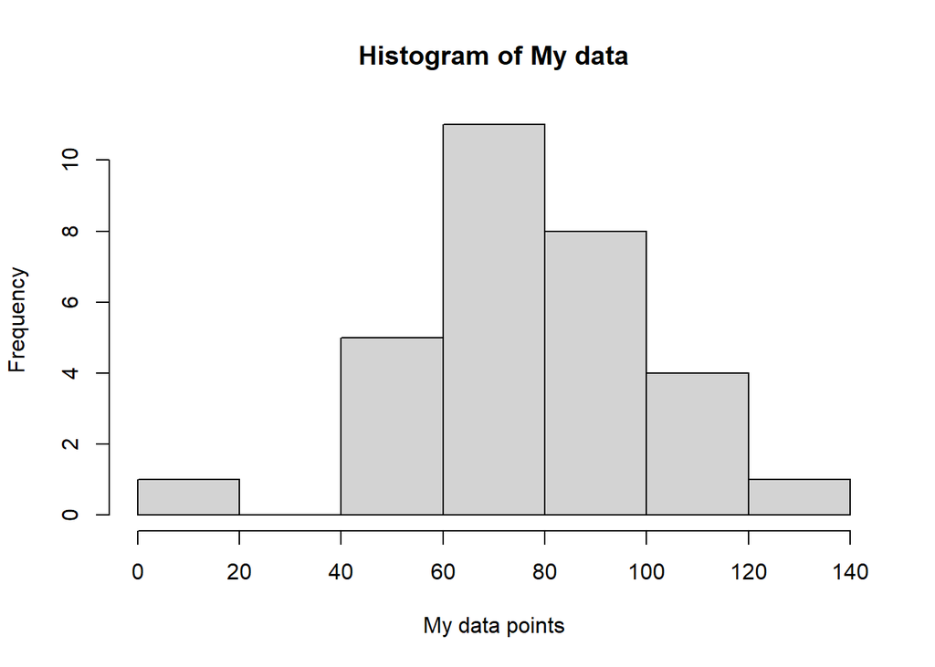

```r
hist(small.size.dataset, xlab='My data points', main='Histogram of My data')
```

Using Density or probability by change frequency as false

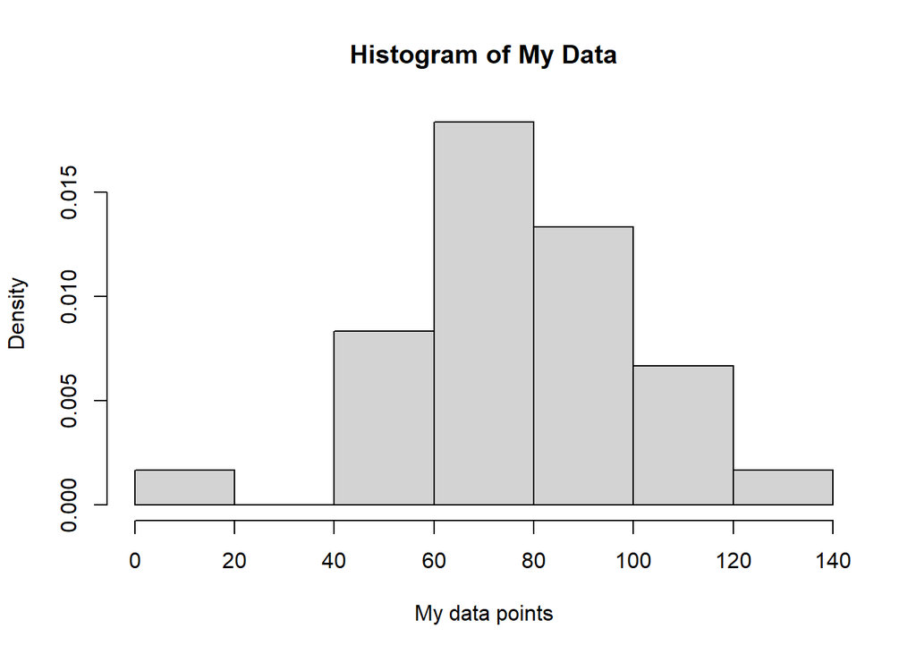

```r
hist(small.size.dataset, xlab='My data points', main='Histogram of My Data', freq=F)
```

Change colour of histogram

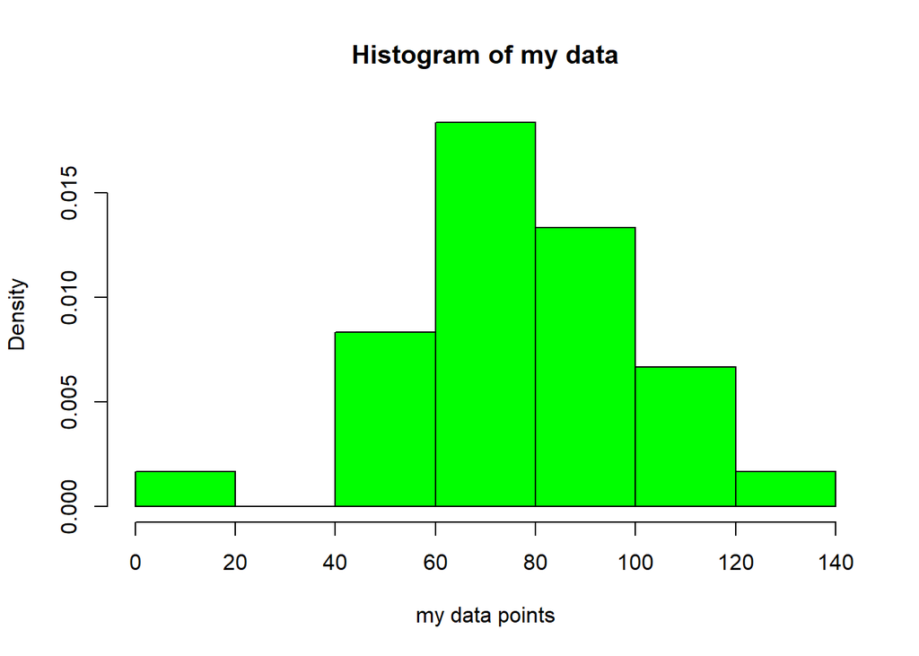

```r
hist(small.size.dataset, xlab='my data points', main='Histogram of my data', freq=F, col='green')
```

Make lines of histogram *note: run bareng

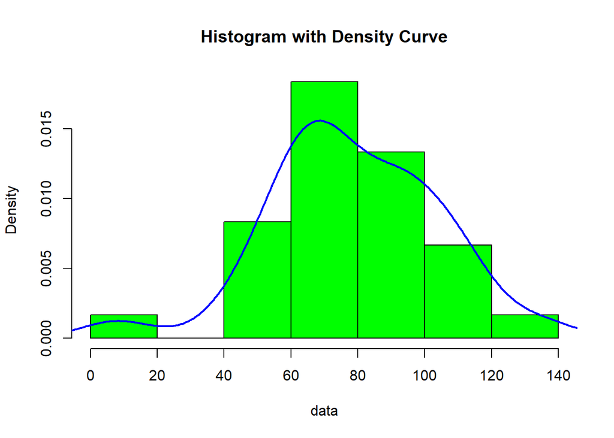

```r
# Membuat histogram dari dataset
hist(small.size.dataset, prob = TRUE, xlab='data',main = "Histogram with Density Curve",col='green')

# Menambahkan garis density
lines(density(small.size.dataset), col = "blue", lwd = 2)
```

Change size of bin by increasing breakpoint

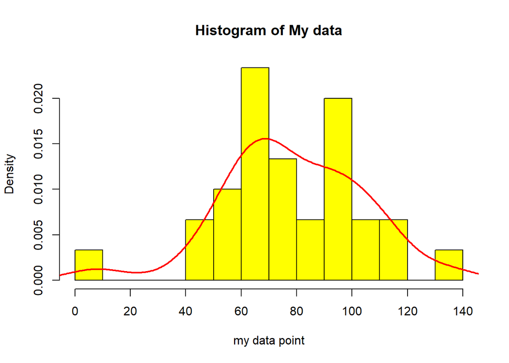

```r
hist(small.size.dataset, xlab='my data point', main="Histogram of My data",freq=F, col='yellow',breaks=10)

lines(density(small.size.dataset), col='red',lwd=2)
```

# 4. Scatterplot in R

what i have learned? I have learned about: - how to plot bivariate data - how to obtain scatterplot with titles and labels.

Pembangkitan bilangan acak atau variabel random.

```r
# set seed for set data to having a same random data.

set.seed(2016)
Test_1_scores=round(rnorm(50,78,10))
Test_2_scores=round(rnorm(50,70,14))
```

Arti rnorm= In R, rnorm adalah fungsi yang digunakan untuk menghasilkan sekumpulan angka acak atau bilangan random yang diambil dari distribusi normal, atau disebut juga dengan pembangkitan bilangan acak dari distribusi normal. Parameter dalam rnorm yaitu rnorm(n,mean,sd). n = banyaknya data yang akan dibangkitkan mean = rata-rata dari data yang akan dibangkitkan (default 0) sd = standar deviasi dari data yang akan dibangkitkan (default 1)

```r
Test_1_scores
```

```
##  [1]  69  88  77  81  50  75  70  71  82  80  74  75  91  69  94  81  69  88  71
## [20]  71  74  71  75  84  80  68  72  91  89  67  68  77  90  63  79  92  70  70
## [39]  73  63  77  83  75  72  87  75  65 100  86  61
```

```r
Test_2_scores
```

```
##  [1] 68 58 35 54 72 47 93 53 65 64 80 79 62 62 77 89 66 54 64 82 83 75 43 70 69
## [26] 81 73 83 70 65 78 77 78 59 49 98 62 79 66 73 89 78 53 80 65 62 72 66 38 87
```

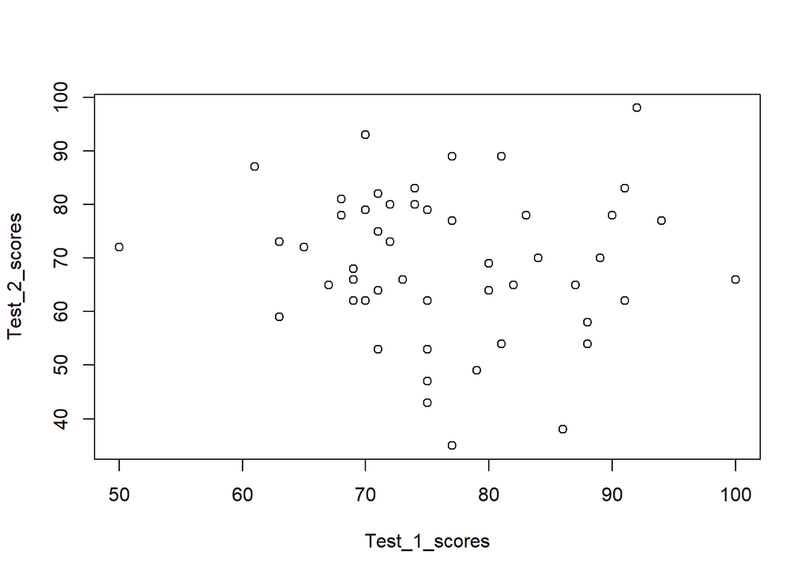

```r
plot(Test_2_scores~Test_1_scores)
```

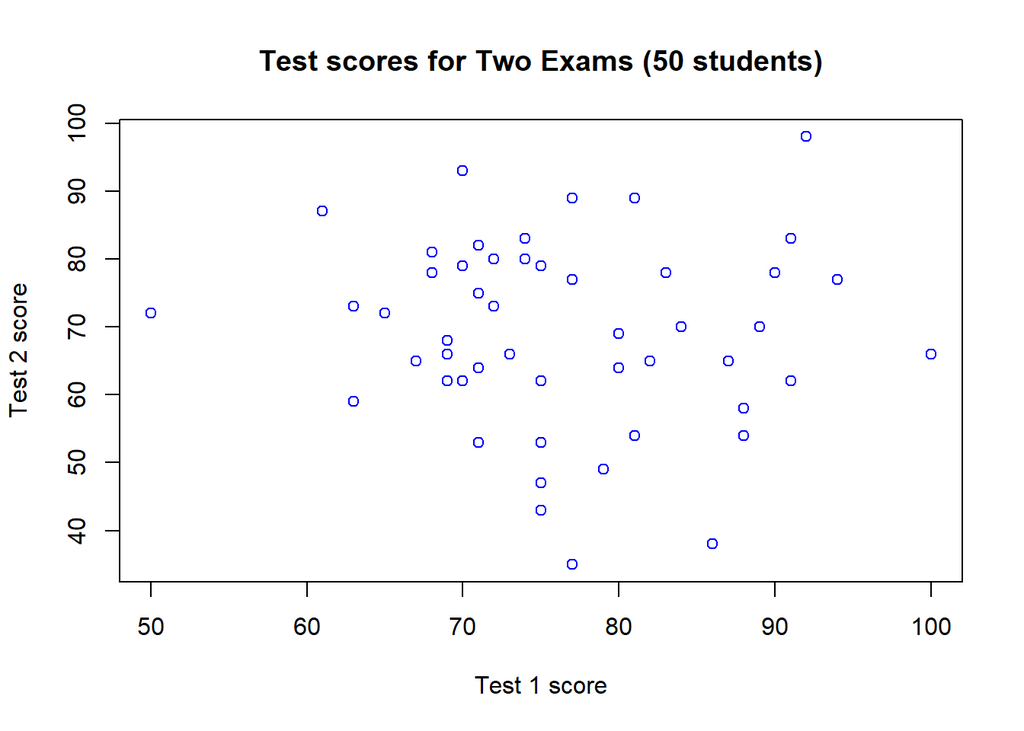

```r
#give a name of x-label, y-label, title of scatterplot, and colour of datapoints

plot(Test_2_scores~Test_1_scores, main='Test scores for Two Exams (50 students)',xlab='Test 1 score',ylab='Test 2 score',col='blue')
```

# 5. Introduction to R - Reviewing Basic Statistics

What we have lerned? We have learned about: - plot time series data - fit a linear model to a set of ordered pairs

## A. Basic Statistics Review - Linear Regression

Objectives: Perform a simple linear regression with R - plot time series data - fit a linear model to a set of ordered pairs - asses normality of residual - test whether the slope of the fitted line is zero

Study Case: Mauna Loa Atmospheric CO2 Concentration

```r
# Load data co2
co2
```

```
##         Jan    Feb    Mar    Apr    May    Jun    Jul    Aug    Sep    Oct
## 1959 315.42 316.31 316.50 317.56 318.13 318.00 316.39 314.65 313.68 313.18
## 1960 316.27 316.81 317.42 318.87 319.87 319.43 318.01 315.74 314.00 313.68
## 1961 316.73 317.54 318.38 319.31 320.42 319.61 318.42 316.63 314.83 315.16
## 1962 317.78 318.40 319.53 320.42 320.85 320.45 319.45 317.25 316.11 315.27
## 1963 318.58 318.92 319.70 321.22 322.08 321.31 319.58 317.61 316.05 315.83
## 1964 319.41 320.07 320.74 321.40 322.06 321.73 320.27 318.54 316.54 316.71
## 1965 319.27 320.28 320.73 321.97 322.00 321.71 321.05 318.71 317.66 317.14
## 1966 320.46 321.43 322.23 323.54 323.91 323.59 322.24 320.20 318.48 317.94
## 1967 322.17 322.34 322.88 324.25 324.83 323.93 322.38 320.76 319.10 319.24
## 1968 322.40 322.99 323.73 324.86 325.40 325.20 323.98 321.95 320.18 320.09
## 1969 323.83 324.26 325.47 326.50 327.21 326.54 325.72 323.50 322.22 321.62
## 1970 324.89 325.82 326.77 327.97 327.91 327.50 326.18 324.53 322.93 322.90
## 1971 326.01 326.51 327.01 327.62 328.76 328.40 327.20 325.27 323.20 323.40
## 1972 326.60 327.47 327.58 329.56 329.90 328.92 327.88 326.16 324.68 325.04
```

[output cut: 65 more lines]

```r
# Mengetahui deskripsi dari data co2
help(co2)
```

```
## starting httpd help server ... done
```

```r
# Mengetahui type data dari co2
class(co2)
```

```
## [1] "ts"
```

Diperoleh informasi bahwa tipe data dari co2 adalah ts yang berarti time series.

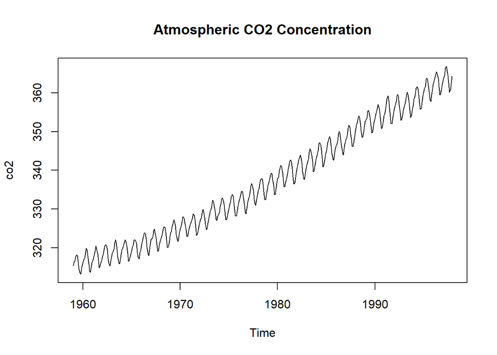

```r
# Melakukan plot dari data time series co2

plot(co2, main='Atmospheric CO2 Concentration')
```

Berdasarkan plot data diatas terlihat bahwa co2 mengalami peningkatan seiring bertambahnya waktu dalam periode ini.

Kita akan membuat beberapa asumsi dan juga mengikuti standar nasional - Respon (konsentrasi co2) dari pengamatan ke-i dapat dilambangkan dengan variabel acak Yi - Respon ini tergantung pada penjelasan variabel xi secara linier, dengan beberapa noise ditambahkan, seperti: Yi= linier model plus noise= b0+b1xi+ei

Istilah kesalahan/error/galat (ei) dapat muncul dalam berbagai cara: - kesalahan pengukuran - kurangnya pengetahuan tentang pengaruh penting lainnya - dll

Saat melakukan model regresi sederhana, kita mengasumsikan bahwa: - galat berdistribusi normal dengan rata-rata 0 - semua galat memiliki varians yang sama (homoskedastik) - galat tidak terkait satu sama lain (galat bersifat independen diseluruh pengamatan)

We can calculate the slope and intercept values by computation:

```r
co2.values=as.numeric(co2)

co2.times=as.numeric(time(co2))

SSxx = sum((co2.times-mean(co2.times))*(co2.times-mean(co2.times)))

SSxy = sum((co2.values-mean(co2.values))*(co2.times-mean(co2.times)))

slope=(SSxy/SSxx)

intercept=mean(co2.values)-(slope*mean(co2.times))
```

Melihat hasil slope dan intercept

```r
slope
```

```
## [1] 1.307497
```

```r
intercept
```

```
## [1] -2249.774
```

Membuat model linier

```r
co2.linear.model=lm(co2~time(co2))
co2.linear.model
```

```
##
## Call:
## lm(formula = co2 ~ time(co2))
##
## Coefficients:
## (Intercept)    time(co2)
##   -2249.774        1.307
```

Membuat plot grafik dari linear model

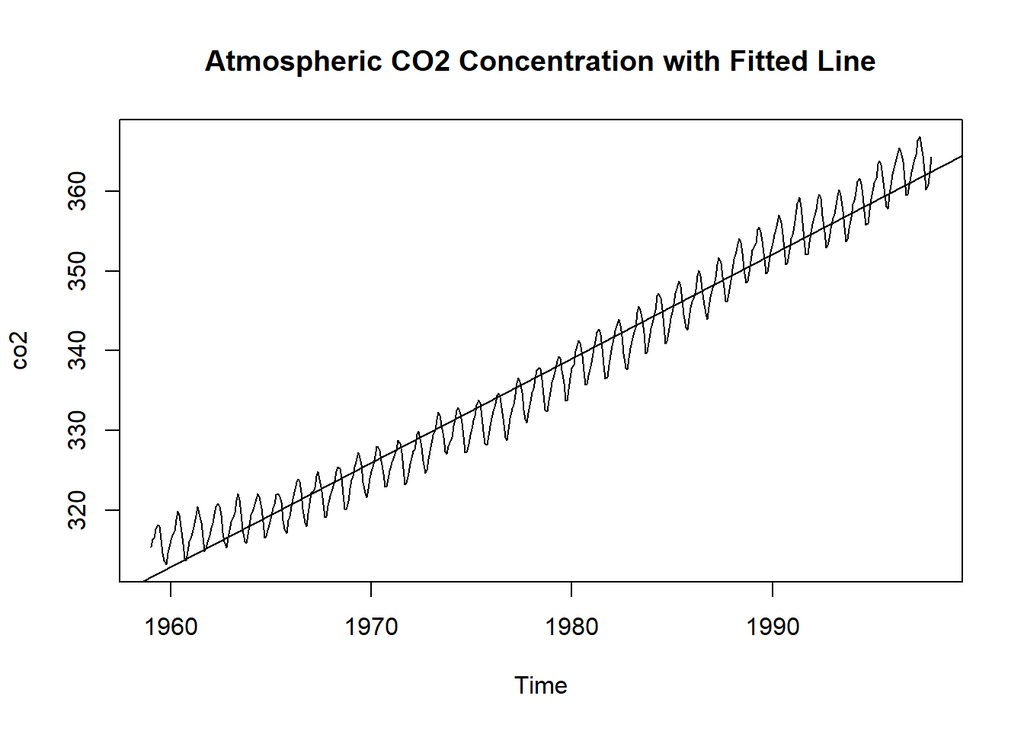

```r
plot(co2,main='Atmospheric CO2 Concentration with Fitted Line')
abline(co2.linear.model)
```

Compute residual by hand or manually

- Asses normality of residuals

```r
co2.fitted.values=slope*co2.times+intercept
co2.residuals=co2.values-co2.fitted.values
```

```r
co2.fitted.values
```

```
##   [1] 311.6118 311.7208 311.8297 311.9387 312.0477 312.1566 312.2656 312.3745
##   [9] 312.4835 312.5924 312.7014 312.8104 312.9193 313.0283 313.1372 313.2462
##  [17] 313.3551 313.4641 313.5731 313.6820 313.7910 313.8999 314.0089 314.1179
##  [25] 314.2268 314.3358 314.4447 314.5537 314.6626 314.7716 314.8806 314.9895
##  [33] 315.0985 315.2074 315.3164 315.4254 315.5343 315.6433 315.7522 315.8612
##  [41] 315.9701 316.0791 316.1881 316.2970 316.4060 316.5149 316.6239 316.7328
##  [49] 316.8418 316.9508 317.0597 317.1687 317.2776 317.3866 317.4956 317.6045
##  [57] 317.7135 317.8224 317.9314 318.0403 318.1493 318.2583 318.3672 318.4762
##  [65] 318.5851 318.6941 318.8031 318.9120 319.0210 319.1299 319.2389 319.3478
##  [73] 319.4568 319.5658 319.6747 319.7837 319.8926 320.0016 320.1105 320.2195
##  [81] 320.3285 320.4374 320.5464 320.6553 320.7643 320.8733 320.9822 321.0912
##  [89] 321.2001 321.3091 321.4180 321.5270 321.6360 321.7449 321.8539 321.9628
##  [97] 322.0718 322.1808 322.2897 322.3987 322.5076 322.6166 322.7255 322.8345
## [105] 322.9435 323.0524 323.1614 323.2703 323.3793 323.4882 323.5972 323.7062
## [113] 323.8151 323.9241 324.0330 324.1420 324.2510 324.3599 324.4689 324.5778
```

[output cut: 44 more lines]

```r
co2.residuals
```

```
##   [1]  3.808180799  4.589222742  4.670264684  5.621306627  6.082348569
##   [6]  5.843390511  4.124432454  2.275474396  1.196516339  0.587558281
##  [11]  1.958600224  2.619642166  3.350684109  3.781726051  4.282767993
##  [16]  5.623809936  6.514851878  5.965893821  4.436935763  2.057977706
##  [21]  0.209019648 -0.219938409  0.831103533  1.912145475  2.503187418
##  [26]  3.204229360  3.935271303  4.756313245  5.757355188  4.838397130
##  [31]  3.539439072  1.640481015 -0.268477043 -0.047435100  0.623606842
##  [36]  1.424648785  2.245690727  2.756732670  3.777774612  4.558816554
##  [41]  4.879858497  4.370900439  3.261942382  0.952984324 -0.295973733
##  [46] -1.244931791 -0.093889849  0.797152094  1.738194037  1.969235979
##  [51]  2.640277921  4.051319864  4.802361806  3.923403749  2.084445691
##  [56]  0.005487633 -1.663470424 -1.992428482 -1.021386539  0.159655403
##  [61]  1.260697346  1.811739288  2.372781231  2.923823173  3.474865115
##  [66]  3.035907058  1.466949000 -0.372009057 -2.480967115 -2.419925172
##  [71] -1.708883230 -0.797841288 -0.186799344  0.714242597  1.055284540
```

[output cut: 79 more lines]

Computation of finding residuals

```r
co2.residuals=resid(co2.linear.model)
co2.residuals
```

```
##            1            2            3            4            5            6
##  3.808180799  4.589222742  4.670264684  5.621306627  6.082348569  5.843390511
##            7            8            9           10           11           12
##  4.124432454  2.275474396  1.196516339  0.587558281  1.958600224  2.619642166
##           13           14           15           16           17           18
##  3.350684109  3.781726051  4.282767993  5.623809936  6.514851878  5.965893821
##           19           20           21           22           23           24
##  4.436935763  2.057977706  0.209019648 -0.219938409  0.831103533  1.912145475
##           25           26           27           28           29           30
##  2.503187418  3.204229360  3.935271303  4.756313245  5.757355188  4.838397130
##           31           32           33           34           35           36
##  3.539439072  1.640481015 -0.268477043 -0.047435100  0.623606842  1.424648785
##           37           38           39           40           41           42
##  2.245690727  2.756732670  3.777774612  4.558816554  4.879858497  4.370900439
##           43           44           45           46           47           48
##  3.261942382  0.952984324 -0.295973733 -1.244931791 -0.093889849  0.797152094
##           49           50           51           52           53           54
##  1.738194037  1.969235979  2.640277921  4.051319864  4.802361806  3.923403749
##           55           56           57           58           59           60
##  2.084445691  0.005487633 -1.663470424 -1.992428482 -1.021386539  0.159655403
##           61           62           63           64           65           66
##  1.260697346  1.811739288  2.372781231  2.923823173  3.474865115  3.035907058
##           67           68           69           70           71           72
##  1.466949000 -0.372009057 -2.480967115 -2.419925172 -1.708883230 -0.797841288
##           73           74           75           76           77           78
## -0.186799344  0.714242597  1.055284540  2.186326482  2.107368425  1.708410367
##           79           80           81           82           83           84
##  0.939452310 -1.509505748 -2.668463806 -3.297421863 -1.846379921 -1.405337978
##           85           86           87           88           89           90
## -0.304296035  0.556745907  1.247787849  2.448829791  2.709871734  2.280913676
##           91           92           93           94           95           96
##  0.821955619 -1.327002439 -3.155960496 -3.804918554 -2.223876611 -1.092834669
##           97           98           99          100          101          102
##  0.098207274  0.159249216  0.590291158  1.851333101  2.322375043  1.313416986
##          103          104          105          106          107          108
## -0.345541072 -2.074499129 -3.843457187 -3.812415245 -2.601373302 -1.470331360
##          109          110          111          112          113          114
## -0.979289416 -0.498247475  0.132794468  1.153836410  1.584878352  1.275920295
##          115          116          117          118          119          120
## -0.053037763 -2.191995820 -4.070953878 -4.269911935 -3.308869993 -1.837828050
```

[output cut: 101 more lines]

```
##  0.965796628  1.406838566  2.357880509  3.548922451  3.859964393  3.021006336
##          427          428          429          430          431          432
##  1.522048278 -0.646909779 -2.405867837 -2.354825894 -0.873783952  0.477257990
##          433          434          435          436          437          438
##  1.298299937  2.239341875  2.760383818  4.471425760  4.702467703  4.073509645
##          439          440          441          442          443          444
##  2.604551588  0.055593530 -1.443364528 -1.862322585 -0.161280643  0.859761300
##          445          446          447          448          449          450
##  2.100803246  3.191845185  3.852887127  4.443929070  5.024971012  4.476012954
##          451          452          453          454          455          456
##  3.057054897  0.788096839 -1.350861218 -1.319819276 -0.278777333  1.192264609
##          457          458          459          460          461          462
##  1.933306556  2.654348494  3.095390436  4.776432379  5.107474321  3.838516264
##          463          464          465          466          467          468
##  2.569558206  0.510600149 -1.928357909 -1.447315967  0.103725976  1.844767918
```

```r
par(mfrow=c(1,3))
(co2.residuals=resid(co2.linear.model))
```

[output not shown]

[output cut: 101 more lines]

[output not shown]

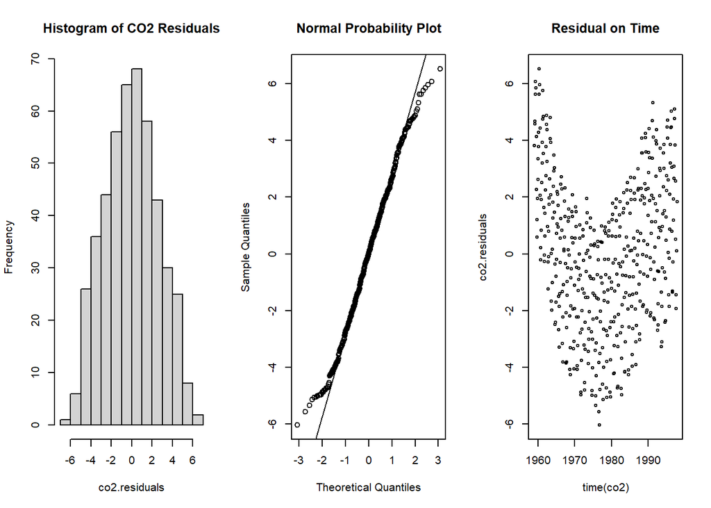

```r
hist(co2.residuals, main='Histogram of CO2 Residuals')
qqnorm(co2.residuals,main='Normal Probability Plot')
qqline(co2.residuals)
plot(co2.residuals~time(co2),main='Residual on Time')
```

Memperbesar plot

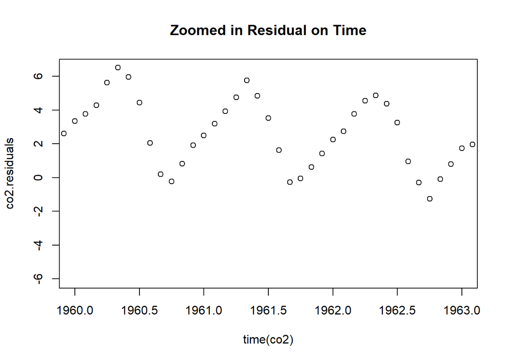

```r
plot(co2.residuals~time(co2),xlim=c(1960,1963),main="Zoomed in Residual on Time")
```

Study case: Student sleep on package ‘sleep’

```r
#Load data sleep
sleep
```

| extra | group | ID |
| --- | --- | --- |
| 0.7 | 1 | 1 |
| -1.6 | 1 | 2 |
| -0.2 | 1 | 3 |
| -1.2 | 1 | 4 |
| -0.1 | 1 | 5 |
| 3.4 | 1 | 6 |
| 3.7 | 1 | 7 |
| 0.8 | 1 | 8 |
| 0.0 | 1 | 9 |
| 2.0 | 1 | 10 |

[output cut: 10 more lines]

```r
# Mencari tau deksripsi of sleep
help(sleep)
```

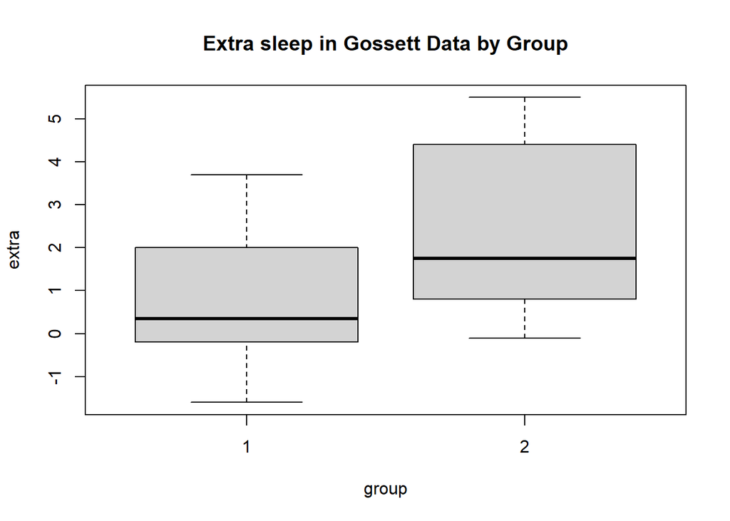

```r
#plot data

plot(extra~group,data=sleep,main='Extra sleep in Gossett Data by Group')
```

Berdasarkan plot diatas, pertanyaan penelitian yang jelas adalah: Apakah ada perbedaaan dalam rata-rata respons terhadap masing-masing dari kedua obat tersebut? Uji yang akan digunakan untuk mengetahui adanya perbedaan rata-rata respons dari kedua obat tersebut yaitu uji mean.

```r
# for change dollar sign with attach
attach(sleep)
```

```r
extra.1=extra[group==1]
extra.2=extra[group==2]
```

```r
t.test(extra.1,extra.2,paired=TRUE,alternative="two.sided")
```

```
##
##  Paired t-test
##
## data:  extra.1 and extra.2
## t = -4.0621, df = 9, p-value = 0.002833
## alternative hypothesis: true mean difference is not equal to 0
## 95 percent confidence interval:
##  -2.4598858 -0.7001142
## sample estimates:
## mean difference
##           -1.58
```

The statistic we have used is the Student-t for the paired differences xd=x−y t=(xbar-0)/(sd/akar(n))

We have a=0.01, if p-value<a = rejected. So, we have p-value=0.002 < a=0.01 means rejected.

Of course, for the test to be meaningful, we assume that the population of differences is normally distributed.

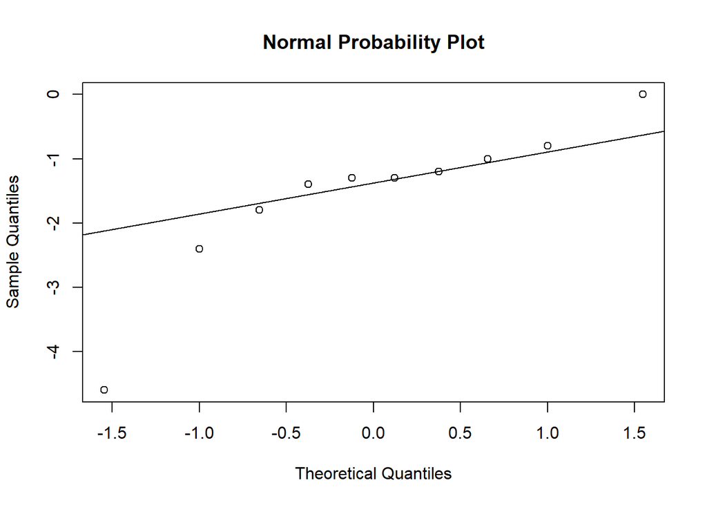

```r
diffs=extra.1-extra.2
qqnorm(diffs, main='Normal Probability Plot')
qqline(diffs)
```

While this is not a very sensitive test for normality, the hypothesis test itself is robust to departures from normality and, while that outlier is somewhat troubling, we can move forward.

## B. Regression Model

Karena data berpasangan atau paired data (yaitu merujuk pada data yang terdiri dari dua nilai yang terkait dengan satu sama lain, biasanya kedua nilai ini berasal dari pengukuran atau observasi yang dilakukan pada subjek atau entitas yang sama didua kondisi atau waktu yang berbeda, data ini sering digunakan dalam statistik untuk membandingkan dua keadaan atau kondisi pada kelompok yang sama, contoh mengukur berta badan seseorang sebelum dan setelah menjalani program diet.) ). Pada data tersebut berarti dua perbedaan repon dari dari setiap obat pada subject yang sama, dapat diplot dalam bentuk (x,y) dengan cara:

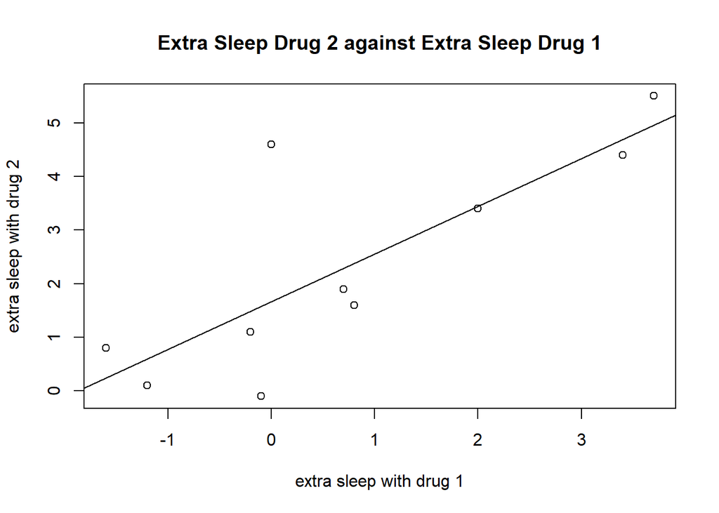

```r
plot(extra.2~extra.1, xlab='extra sleep with drug 1', ylab='extra sleep with drug 2', main='Extra Sleep Drug 2 against Extra Sleep Drug 1')
sleep.linear.model=lm(extra.2~extra.1)
abline(sleep.linear.model)
```

Regresi dari residual

```r
summary(sleep.linear.model)
```

```
##
## Call:
## lm(formula = extra.2 ~ extra.1)
##
## Residuals:
##     Min      1Q  Median      3Q     Max
## -1.6735 -0.4673 -0.3365  0.3979  2.9375
##
## Coefficients:
##             Estimate Std. Error t value Pr(>|t|)
## (Intercept)   1.6625     0.4452   3.734  0.00575 **
## extra.1       0.8899     0.2399   3.709  0.00596 **
## ---
## Signif. codes:  0 '***' 0.001 '**' 0.01 '*' 0.05 '.' 0.1 ' ' 1
##
## Residual standard error: 1.288 on 8 degrees of freedom
## Multiple R-squared:  0.6323, Adjusted R-squared:  0.5863
## F-statistic: 13.76 on 1 and 8 DF,  p-value: 0.005965
```

Our model is then: extra.2 = 0.8899.extra. 1 + 1.6625

Following questions: 1. What do you predict for sleep gained with drug 2 if you know the sleep gained with drug 1 is 2 hours?

```r
extra2 = 0.8899*2 + 1.6625
extra2
```

```
## [1] 3.4423
```

So, predicted for sleep gained with drug 2 if knowing the sleep gained with drug 1 is 2 hours is 3.4423 hours.

2. What is the residual associated with the 3rd data point?

```r
residuals = resid(sleep.linear.model)
residuals[3]
```

```
##          3
## -0.3845478
```

```r
# alternative
resid3 = extra.2[3]-(0.8899*extra.1[3]+1.6625)
resid3
```

```
## [1] -0.38452
```